# An R Workbook for Topic Modeling with LDA

2/25/2019

# Introduction

This document is an R companion to the methods note. This document was created using R markdown (Allaire et al. 2015). There is an R markdown file associated with this document that contains the text and code of this document. This R markdown file is named lda-workbook.Rmd and is provided along with the data used within this document and the main article. The data for this document is in the file **you need to create** named equity.csv (see the document **twitter-archiver-readme** in the zip file). If you would like to “Knit” the .Rmd file with this data from your own machine, launch Rstudio and open this .Rmd. file, change the file path to the equity.csv data (see Read Text Data into R section below), and finally click the “knit” button (For further discussion on this see the document named README in the zip file). Note, you may receive an error that you need to install the packages used within this document if they are not already on your machine. It is assumed that the user has R and Rstudio on their machine.

The purpose of this document is to demonstrate how to use Latent Dirichlet Allocation (LDA) for topic modeling in R as well as provide “boilerplate code” for users. Boilerplate code is code that can be used with little or no alteration. The code and figures for topic modeling in R are discussed throughout. The remaining sections of this document, and steps in the process of analyzing text data with LDA in R, are:

1. Reading text data into R,
2. Cleaning the text data,
3. Tokenizing text data, removing stopwords, and creating N-grams,
4. Creating a document term matrix,
5. LDA tuning with ldatuning package, and
6. Topic modeling using LDA with the topicmodels package.

# Step 1) Read Text Data into R

```r
# read data with rio package. save to tweets object. (1)
tweets <- rio::import(here::here("equity.csv"), encoding="UTF-8")

# names for variables in dataset (2)
names(tweets) <- c("date","tweet", "retweets", "favs",
                   "followers", "follows")

# remove duplicated tweets (3)
tweets = tweets[!duplicated(tweets$tweet),]

# convert to tibble (4)
tweets <- dplyr::as_tibble(tweets)

# create unique id for each tweet (5)
tweets <- dplyr::mutate(tweets, id = rownames(tweets))

# rename id to tweetid (6)
names(tweets) <- c("date","tweet", "retweets", "favs",
                   "followers", "follows", "tweetid")

# display data in tibble format
tweets
```

```
## # A tibble: 12,803 x 7
##    date             tweet               retweets  favs followers follows tweetid
##    <chr>            <chr>                  <int> <int>     <int>   <int> <chr>
##  1 01/02/2022 06:25 "This #BlackHistor~        0     0      6898    4482 1
##  2 01/02/2022 06:24 "Before you dismis~        1     0        57     150 2
##  3 01/02/2022 06:23 "Market Budget Mov~        0     0       223       7 3
##  4 01/02/2022 06:22 "\"\"when engaging~        0     0       901    1380 4
##  5 01/02/2022 06:18 "On the Hill: Bipa~        0     1      7661    3009 5
##  6 01/02/2022 06:18 "In the @AGACGFM F~        0     0      1781    4870 6
##  7 01/02/2022 06:17 "Glad to support o~        0     0       152     637 7
##  8 01/02/2022 06:16 "Three ways to imp~        0     0       898    2489 8
##  9 01/02/2022 06:15 "The path to true ~        1     0       182     293 9
## 10 01/02/2022 06:13 "In honor all Asia~        1     0        40      16 10
## # ... with 12,793 more rows
```

# Step 2) Clean Data

```r
# cleaning strings function
# the function executes a set of procedures on a set of texts
textprocess <- function(texts = texts){
  # import libraries
  library(stringr)
  library(textclean)

  # manipulate texts
  texts = str_to_lower(texts) # tolower (1)
  texts = gsub('[[:punct:] ]+',' ',texts) # remove punctuation (2)
  texts = str_replace_all(texts, "[^[:alnum:]]", " ") # replace alphanumbers with space (3)
  texts = strip(texts) # fnc to remove unwanted symbols (4)
  texts = gsub(" *\\b(?<!-)\\w{1,2}(?!-)\\b *", " ", texts, perl=T) # removing any special characters (5)

  # return texts
  texts
}

# clean data by running function
tweets$tweet<- textprocess(texts = tweets$tweet)

# display data
tweets
```

```
## # A tibble: 12,803 x 7
##    date             tweet               retweets  favs followers follows tweetid
##    <chr>            <chr>                  <int> <int>     <int>   <int> <chr>
##  1 01/02/2022 06:25 "this blackhistory~        0     0      6898    4482 1
##  2 01/02/2022 06:24 "before you dismis~        1     0        57     150 2
##  3 01/02/2022 06:23 "market budget mov~        0     0       223       7 3
##  4 01/02/2022 06:22 "when engaging col~        0     0       901    1380 4
##  5 01/02/2022 06:18 " the hill biparti~        0     1      7661    3009 5
##  6 01/02/2022 06:18 " the agacgfm fall~        0     0      1781    4870 6
##  7 01/02/2022 06:17 "glad support our ~        0     0       152     637 7
##  8 01/02/2022 06:16 "three ways improv~        0     0       898    2489 8
##  9 01/02/2022 06:15 "the path true equ~        1     0       182     293 9
## 10 01/02/2022 06:13 " honor all asian ~        1     0        40      16 10
## # ... with 12,793 more rows
```

Notice the changes in the tweet column of the data. No longer do we have punctuation, capital letters, or unwanted symbols.

# Step 3) Tokenizing data, Removing Stopwords, and Creating N-grams

The next set of code shows us how to create N-grams after removing stopwords (stopwords are discussed below). The process of creating N-grams is way of tokenizing the data. That is, we are spliting the text into a set of tokens. These tokens could be 1-word, a pair of words, or an entire paragraph. Below, we show how to create 1-word tokens (unigrams) and pairs of words tokens (bigrams). The first step in the code is to tokenize the data into a set of words (unigrams). We accomplish this using the dyplr package and the tidytext package (Silge and Robinson 2016). Using the object tweets, we call the unnest_tokens function by stating that we want to create a column of single words named “word” using the column of tweets. We specify that the tokens are n-grams of n=1. The resulting data are displayed below the code chunk.

```r
library(dplyr)
# tokenize data with unnest_tokens (1 word tokens)
# we will create bigrams using the tokenized unigram data
tweet_unigrams <- tweets %>%
  tidytext::unnest_tokens(word, tweet, token = "ngrams", n =1)

tweet_unigrams
```

```
## # A tibble: 337,567 x 7
##    date             retweets  favs followers follows tweetid word
##    <chr>               <int> <int>     <int>   <int> <chr>   <chr>
##  1 01/02/2022 06:25        0     0      6898    4482 1       this
##  2 01/02/2022 06:25        0     0      6898    4482 1       blackhistorymonth
##  3 01/02/2022 06:25        0     0      6898    4482 1       are
##  4 01/02/2022 06:25        0     0      6898    4482 1       excited
##  5 01/02/2022 06:25        0     0      6898    4482 1       celebrate
##  6 01/02/2022 06:25        0     0      6898    4482 1       black
##  7 01/02/2022 06:25        0     0      6898    4482 1       excellence
##  8 01/02/2022 06:25        0     0      6898    4482 1       and
##  9 01/02/2022 06:25        0     0      6898    4482 1       shine
## 10 01/02/2022 06:25        0     0      6898    4482 1       light
## # ... with 337,557 more rows
```

```r
# custom stopwords
# note there is a default dictionary used here (see ?stop_words)
library(tidytext)
custom_stop_words_tweet <- bind_rows(data_frame(word = c("equity"), lexicon = c("custom")), stop_words)

# remove stopwords
tweet_unigrams_nostop <- tweet_unigrams %>%
  anti_join(custom_stop_words_tweet)
```

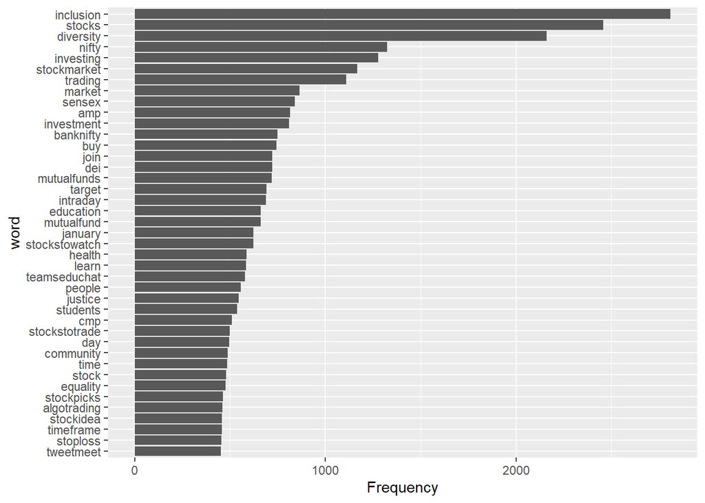

```r
library(ggplot2)
tweet_unigrams_nostop %>%
  count(word, sort = TRUE) %>%
  filter(n > 450) %>%
  mutate(word = reorder(word, n)) %>%
  ggplot(aes(word, n)) +
  geom_col() +
  ylab("Frequency") +
  coord_flip()
```

To create bigrams, we use the set of unigrams with the stopwords removed. Using the object tweet_unigrams_nostop, we call the unnest_tokens function by stating we want to create a column of bigrams named “bigrams” using the column of word in the tweet_unigrams_nostop tibble. We specify that the tokens are n-grams of n=2. Lastly, we move the columns of word and bigram to the front of the dataframes using the indexing command [,c(7,1:6)]. This can be useful if you want to use the tweet attribute data in subsequent analysis. Otherwise, in the steps below, the data would be lost if the column of words and bigrams were kept at the end of the dataset or tibble.

```r
# create bigrams from unigrams
tweet_bigrams_nostop <- tweet_unigrams_nostop %>%
  tidytext::unnest_tokens(bigram, word, token = "ngrams", n =2)

# arrange first column to word
# this is important for data to be carried forward in later
# analysis using the tidytext approach
tweet_unigrams_nostop <- tweet_unigrams_nostop[,c(7,1:6)]
tweet_bigrams_nostop <- tweet_bigrams_nostop[,c(7,1:6)]

tweet_bigrams_nostop
```

```
## # A tibble: 223,148 x 7
##    bigram date             retweets  favs followers follows tweetid
##    <chr>  <chr>               <int> <int>     <int>   <int> <chr>
##  1 <NA>   01/02/2022 06:25        0     0      6898    4482 1
##  2 <NA>   01/02/2022 06:25        0     0      6898    4482 1
##  3 <NA>   01/02/2022 06:25        0     0      6898    4482 1
##  4 <NA>   01/02/2022 06:25        0     0      6898    4482 1
##  5 <NA>   01/02/2022 06:25        0     0      6898    4482 1
##  6 <NA>   01/02/2022 06:25        0     0      6898    4482 1
##  7 <NA>   01/02/2022 06:25        0     0      6898    4482 1
##  8 <NA>   01/02/2022 06:25        0     0      6898    4482 1
##  9 <NA>   01/02/2022 06:25        0     0      6898    4482 1
## 10 <NA>   01/02/2022 06:25        0     0      6898    4482 1
## # ... with 223,138 more rows
```

# Step 4) Create Document-Term Matrix

To conduct topic modeling with Latent Dirichlet Allocation (LDA) in the topicmodels package, we need to have our data in the form of a “DocumentTermMatrix.” A Document Term Matrix (DTM), is a matrix that describes the fequency of words in the collection of documents (here tweets). In a DTM, the rows correspond to the documents in our collection of documents and the columns refer to the terms used across the documents. Again, we will utilize the dplyr and tidytext packages. The steps to create the document term matrix are 1) create a count of a specific word for a given document (tweet) and then sort them by the word with the largest frequency use, 2) create a count of the total number of words used by a given document (tweet), and 3) join the two counts by document together into one tibble or dataframe (tweet_unigrams_counts object below), and 4) cast the data using tidytext into a DTM with the function cast_dtm from the tidytext package.

```r
library(dplyr)
library(tidytext)

# counts words by id and sort by greatest n (1)
tweet_unigrams_word_counts  <- tweet_unigrams_nostop %>%
  count(tweetid, word, sort = TRUE) %>%
  ungroup()

# creating total words used by id (2)
tweet_unigrams_total_counts <- tweet_unigrams_word_counts %>%
  group_by(tweetid) %>%
  summarize(total = sum(n))

# joining two tables by id (3)
tweet_unigrams_counts <- left_join(tweet_unigrams_word_counts, tweet_unigrams_total_counts)

# cast into a Document-Term Matrix (4)
tweet_unigrams_words_dtm <- tweet_unigrams_counts  %>%
  tidytext::cast_dtm(tweetid, word, total)

tweet_unigrams_words_dtm
```

```
## <<DocumentTermMatrix (documents: 12802, terms: 33542)>>
## Non-/sparse entries: 203991/429200693
## Sparsity           : 100%
## Maximal term length: 37
## Weighting          : term frequency (tf)
```

# Step 5) LDA Tuning with ldatuning package

The next set of code is not executed here because the function FindTopicsNumber takes a few minutes to run. The results of this function call to the data are reported in the main article. The FindTopicsNumber and FindTopicsNumber_plot functions are from the ldatuning package (Nikita 2016). The parameters of the function are discussed here breifly. For more information on the function, after loading the package ldatuning write ?FindTopicsNumber into the R console. The result of the FindTopicsNumber is saved to an object called result and this object is then used in the FindTopicsNumber_plot function that plots the results. The options or paramters of the FindTopicNumber function include 1) telling the function what the object is (here a document term matrix), 2) telling the function how many topic solutions to explore (here 2 to 16 by 2), 3) specify the metrics to compute (here only Arun2010 and Deveaud2014 are used - other options include Griffiths2004 and CaoJuan2009), 4) specify the estimation procedure (here gibbs), 5) specify a list of options to control the function (here we do not set a seed and set verbose to print the results as the function runs), 6) specify the number of cores on your machine, and 7) allow warnings to be reported by the function. Using the ldatuning package, we have a method that can help us determine the number of topics we should use in our LDA solution.

```r
library(ldatuning)

# fit methods for finding the number of topics using FindTopicsNumber Function
# function is part of the ldatuning package
# use ?FindTopicsNumber in console to examine function options
result <- FindTopicsNumber(
  dtm = tweet_unigrams_words_dtm, # data (1)
  topics = seq(from = 2, to = 16, by = 2),# topics (2)
  metrics = c("Arun2010", "Deveaud2014"), # metrics (3)
  method = "Gibbs", # Using gibbs sampling (4)
  control = list(seed = NA, verbose = 1), # setting seed (5)
  mc.cores = 2, # use two cores (6)
  verbose = TRUE # allows warnings (7)
)

# plot data
FindTopicsNumber_plot(result)
```

# Step 6) Topic Modeling using LDA with topicmodels package

To carryout topic modeling in R with LDA, we can use the topicmodels package. For more information on the topicmodels package, topic modeling, and LDA, the reader is encouraged to visit the {tidytextmining}(https://www.tidytextmining.com) website. In the demonstration below, the choice of two topics to discuss the code and functions is arbitrarily made. The four topic and eight topic solutions are also reported for investigation here. The four topic solution in discussed in the manuscript associated with this workbook. We use three packages to use LDA for topic modeling in R: ggplot2 (Wickham 2016), dplyr, and topicmodels (Grün and Hornik 2011).

## Two-topic LDA

In LDA, every document (tweet) is modeled as a mixture of topics and every topic as a mixture of words (Silge and Robinson 2016). We fit the LDA model using the LDA function in the topicmodels package (see section 1 of the code chunk below). The LDA function takes as inputs the DTM, the estimation method (here we use the variational expectation-maximization method), and a list of controls. The LDA function and options are not discussed here but are discussed in the manuscript associated with this workbook. When using LDA, for each word and topic pair, a probability of belonging to a topic is estimated and stored in a matrix called beta (see section 2 of the code chunk below).Likewise, for each document and topic pair, a probability of belonging to a topic is estimated and stored in a matrix called gamma (see section 3 of the second code chunk below). We extract these matrices with the tidy function from tidytext. The beta matrix is visualized in the figure below the following code chunk. The figure is created by first organizing the beta tibble matrix by sorting the probabilities of words belonging to a topic by descending probability. Then we convert the topic to a factor and use ggplot2 to visualize the top 15 probabilities by topics. The components of the code for the ggplot2 figure code are not discussed here.

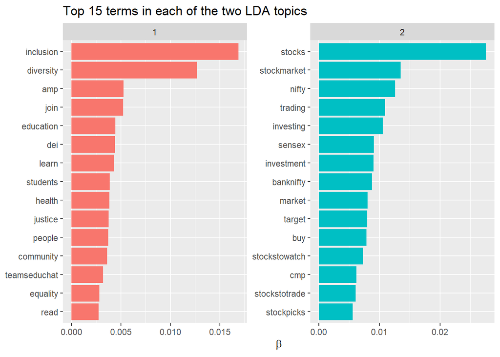

Word-Topic Probabilities

```r
library(ggplot2)
library(dplyr)
library(topicmodels)

# four topics unigram (1)
tweet_unigrams_lda <- LDA(tweet_unigrams_words_dtm, method = "VEM", k = 2, control = list(seed = 1234, estimate.alpha = T, estimate.beta = T))

# beta matrix P(word|topic) (2)
tweet_word_topic <- tidy(tweet_unigrams_lda, matrix = "beta")

# top terms
tweet_lda_top_terms <- tweet_word_topic %>%
  group_by(topic) %>%
  top_n(15, beta) %>%
  ungroup() %>%
  arrange(topic, -beta)

# covert to factor
tweet_lda_top_terms$topic <- factor(tweet_lda_top_terms$topic)

# plot top 15 Terms in each LDA topic
tweet_lda_top_terms %>%
  mutate(term = reorder(term, beta)) %>%
  group_by(topic, term) %>%
  arrange(desc(beta)) %>%
  ungroup() %>%
  mutate(term = factor(paste(term, topic, sep = "__"),
                       levels = rev(paste(term, topic, sep = "__")))) %>%
  ggplot(aes(term, beta, fill = as.factor(topic))) +
  geom_col(show.legend = FALSE) +
  coord_flip() +
  scale_x_discrete(labels = function(x) gsub("__.+$", "", x)) +
  labs(title = "Top 15 terms in each of the two LDA topics",
       x = NULL, y = expression(beta)) +
  facet_wrap(~ topic, ncol = 2, scales = "free")
```

Likewise, we can visualize the topic by document probabilities (i.e., the gamma matrix). In the figure below the next code chunk, we see the distribution of the probabilities in gamma across all tweets Note, the y-axis is plotted on a log scale to make out the details of the plot.The plot indicates that the two topics were highly discriminating in terms of classifying the tweets. That is, we can see that the majority of the documents had gamma probabilities estimated as either a 0 or a 1. This finding indicates that the majority of tweets could be classified by the word usage given by the two topics. However, there were notably a number of tweets that had probabilities that were close to 0.5 indicating an even distribution of topic usage across the tweet.

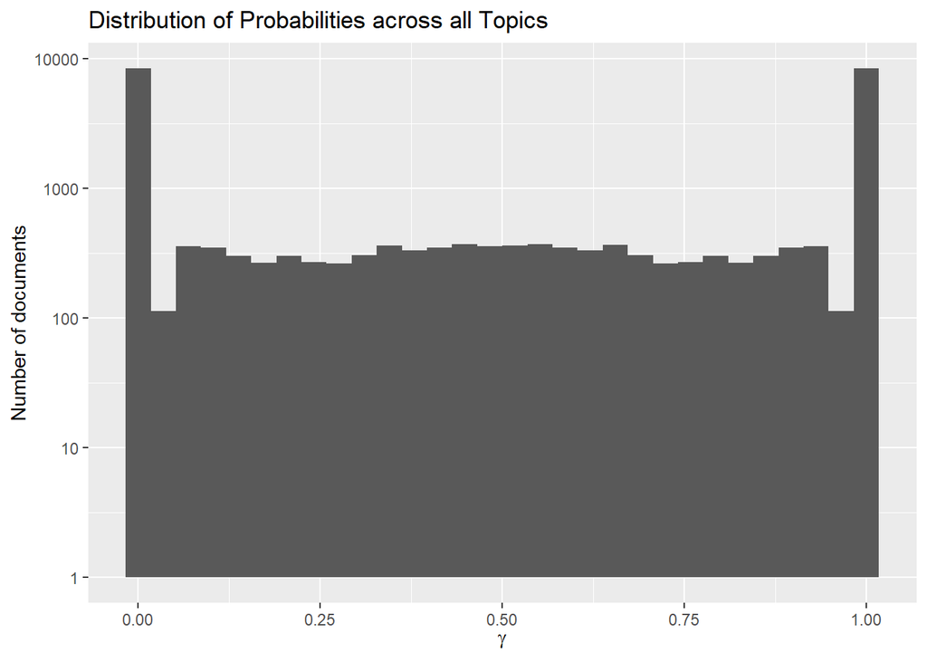

Document-Topic Probabilities

```r
library(ggplot2)
# gamma matrix P(topic|document) (3)
tweet_topic_document <- tidy(tweet_unigrams_lda, matrix = "gamma")

# Distribution of $\gamma$ for all Topics
ggplot(tweet_topic_document, aes(gamma)) +
  geom_histogram() +
  scale_y_log10() +
  labs(title = "Distribution of Probabilities across all Topics",
       y = "Number of documents", x = expression(gamma))
```

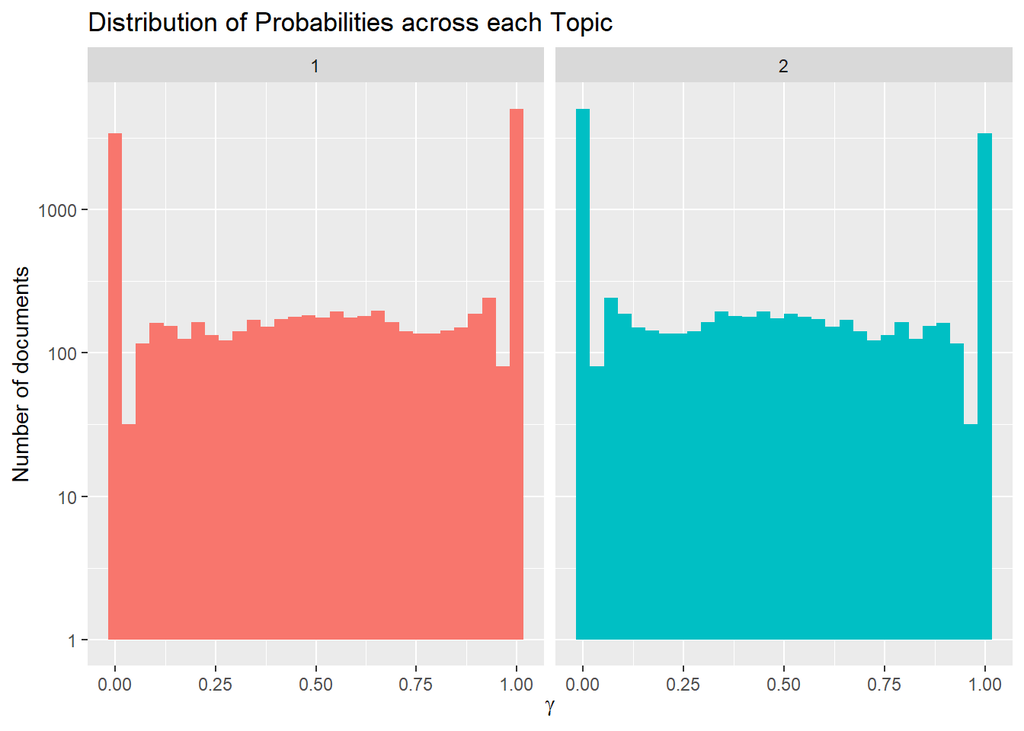

Document-Topic Probabilities

```r
library(ggplot2)

# Distribution of $\gamma$ for each Topic
ggplot(tweet_topic_document, aes(gamma, fill = as.factor(topic))) +
  geom_histogram(show.legend = FALSE) +
  facet_wrap(~ topic, ncol = 4) +
  scale_y_log10() +
  labs(title = "Distribution of Probabilities across each Topic",
       y = "Number of documents", x = expression(gamma))
```

We can examine a specific tweet based on it’s gamma probability to see how the classification performed. For example, let us filter the tweets that had a probability greater than 0.95 on topic 1.

```r
library(dplyr)

# filter tweet great than 0.95 and topic equal to 1
tweet_topic_document %>% filter(gamma > 0.95 & topic == 1)
```

```
## # A tibble: 5,135 x 3
##    document topic gamma
##    <chr>    <int> <dbl>
##  1 2762         1  1.00
##  2 10094        1  1.00
##  3 11535        1  1.00
##  4 1312         1  1.00
##  5 1972         1  1.00
##  6 291          1  1.00
##  7 3718         1  1.00
##  8 3918         1  1.00
##  9 4850         1  1.00
## 10 5371         1  1.00
## # ... with 5,125 more rows
```

Let’s focus on document 1037. Note, this ID corresponds to the row number in the original equity.csv file. This is due to the nature of how the IDs were created in the first code chunk of this document. **NOTE! The code below will be commented out in the actual .RMD file. This is because you will be using your equity.csv file. Therefore, you need to supply that line of code with a document number from your equity.csv file**

```r
tweets[tweets$tweetid == 1037, ]$tweet
```

```
## [1] "please read this short thread think about with both your mind and your heart then tweet  that others may have their eyes opened what many people through every day their lives thank you victoria can better together disability equity poverty vabvox today day since was paralyzed cannot begin te…
```